# hw-03

Lucio Di Meo (S2912479)

2026-11-19

## Data load and preparation before modelling

```r
gss16<-read.csv("data/gss16.csv")
```

#### Cleaning and selecting columns

```r
gss16_advfront <- gss16 %>%
  select(advfront, emailhr, educ, polviews, wrkstat) %>%
  drop_na()
```

#### Re-leveling `advfront`

```r
gss16_advfront <- gss16_advfront %>%
  mutate(
    advfront = case_when(
      advfront == "Strongly agree" ~ "Agree",
      advfront == "Agree" ~ "Agree",
      TRUE ~ "Not agree"
    ),
    advfront = fct_relevel(advfront, "Not agree", "Agree")
  )
```

#### Re-levelling `polviews`

```r
gss16_advfront <- gss16_advfront %>%
  mutate(
    polviews = case_when(
      str_detect(polviews, "[Cc]onservative") ~ "Conservative",
      str_detect(polviews, "[Ll]iberal") ~ "Liberal",
      TRUE ~ polviews
    ),
    polviews = fct_relevel(polviews, "Conservative", "Moderate", "Liberal")
  )
```

## Exercise 1: Create a linear regression model

#### Exercise 1 (a)

```r
#Fit a linear regression model to predict emailhr based on the educ. From your output, state the formula for the line-of-best fit and give an interpretation of the emailhr estimate. (2 pts)

model1 <- lm( emailhr ~ educ, data =  gss16_advfront )
model1_coefs<- tidy(model1)
model1_coefs
```

```
## # A tibble: 2 × 5
##   term        estimate std.error statistic       p.value
##   <chr>          <dbl>     <dbl>     <dbl>         <dbl>
## 1 (Intercept)   -2.76      1.66      -1.66 0.0970
## 2 educ           0.685     0.116      5.92 0.00000000413
```

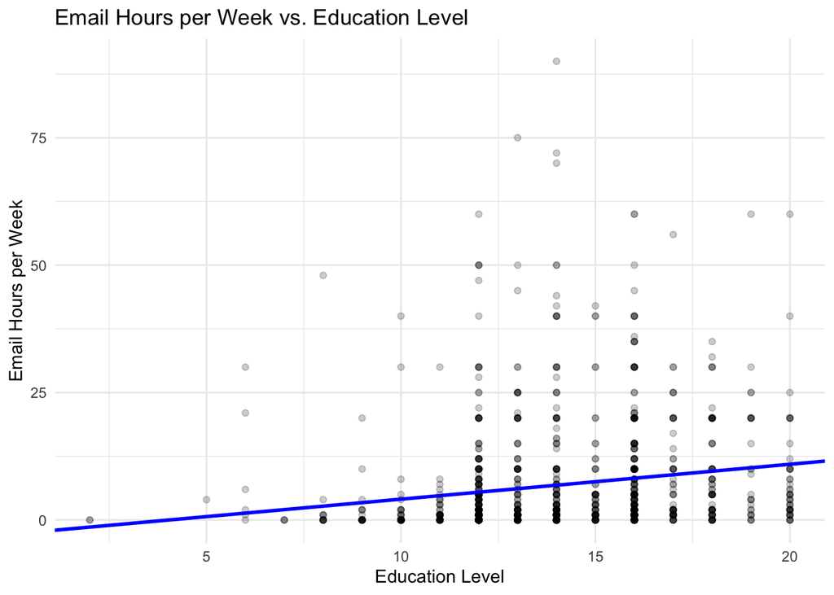

```r
ggplot(gss16_advfront, aes(x = educ, y = emailhr)) +
  geom_point(alpha = 0.2) +
  geom_abline(intercept = model1_coefs$estimate[1], slope = model1_coefs$estimate[2], color = "blue", linewidth = 1) +
  labs( title = "Email Hours per Week vs. Education Level",
        x = "Education Level", y = "Email Hours per Week") +
  theme_minimal()
```

The regression line shows positive correlation between level of education and time spent reading emails. The equation for the regression line is emailhr=-2.757 +0.685*educ, this means for every extra year spent in education, the model predicts an extra 0.685 more hours per week spent on email on average.

#### Exercise 1 (b)

```r
glance(model1)
```

```
## # A tibble: 1 × 12
##   r.squared adj.r.squared sigma statistic       p.value    df logLik   AIC   BIC
##       <dbl>         <dbl> <dbl>     <dbl>         <dbl> <dbl>  <dbl> <dbl> <dbl>
## 1    0.0291        0.0283  10.9      35.1 0.00000000413     1 -4458. 8922. 8937.
## # ℹ 3 more variables: deviance <dbl>, df.residual <int>, nobs <int>
```

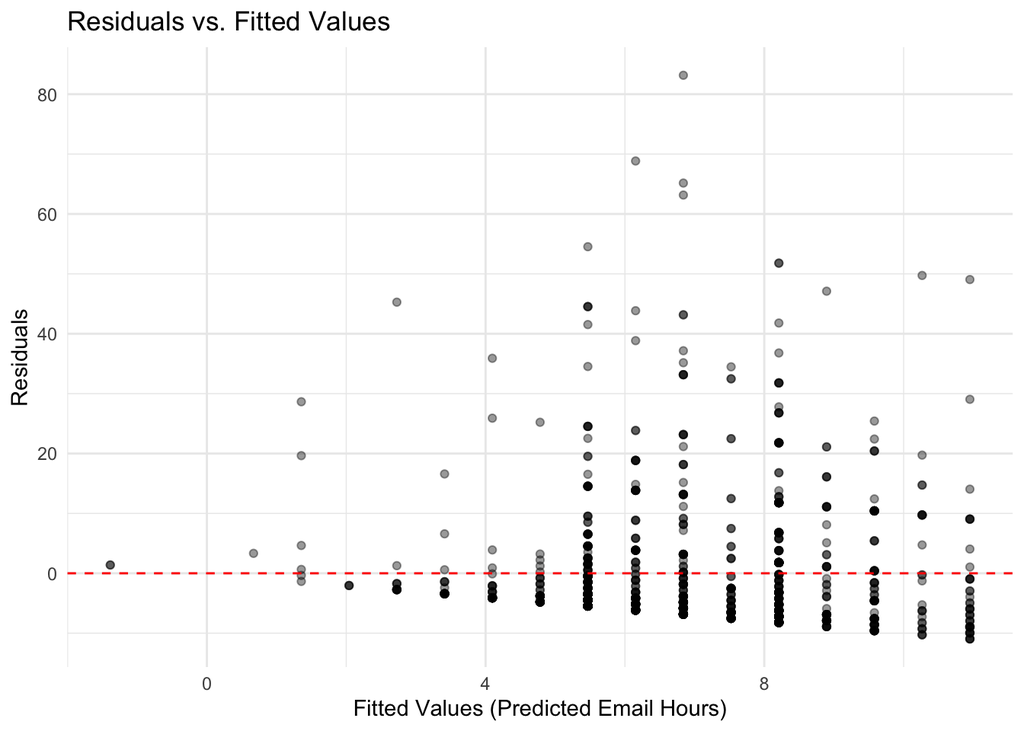

```r
model_aug <- augment(model1, new_data = gss16_advfront)

ggplot(model_aug, aes(x = .fitted, y = .resid)) +
  geom_point(alpha = 0.4) +
  geom_hline(yintercept = 0, color = "red", linetype = "dashed") +
  labs(title = "Residuals vs. Fitted Values",
       x = "Fitted Values (Predicted Email Hours)", y = "Residuals") +
  theme_minimal()
```

The model’s R squared value is only 0.029 which means education level is only explain a very small proportion of the variance found in the values for email usage. This means most the variation in the email usage is driven by other factors.

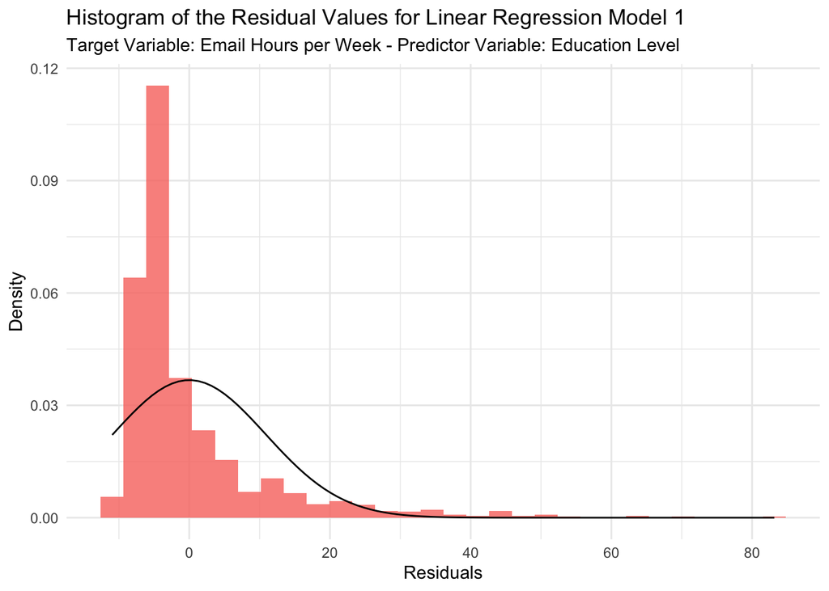

```r
ggplot(model_aug, aes(x=.resid))+
  geom_histogram(bins = 30, alpha= 0.8, aes(y = after_stat(density), fill = "orange")) +
  stat_function(fun = dnorm, args = list(mean = mean(model_aug$.resid), sd = sd(model_aug$.resid))) +
  theme_minimal()+
  theme(legend.position = "none")+
  labs(x="Residuals",y="Density",title = "Histogram of the Residual Values for Linear Regression Model 1",
       subtitle = "Target Variable: Email Hours per Week - Predictor Variable: Education Level")
```

Residuals clearly not normally distributed about 0 as residuals fan out when compared for the fitted values and histogram looks nothing like the fitted normal distribution, so second assumption that for linear regression model the residuals are normally distributed about 0 is violated.

Whilst the model does capture still captures an overall positive correlation between email usage and education level, it leaves a huge amount of variance unexplained in the time spent using emails each week, and the model violates several assumptions needed for the use of a linear regression to be suitable. Because the residuals don’t appear to meet the assumptions very well, we should be careful when interpreting the p-values and confidence intervals from this model.

## Exercise 2: Compare two linear models

#### Exercise 2 (a)

```r
#create model for emailhr with predictive variables educ and advfront
model2 <- lm(emailhr ~ educ + advfront, data = gss16_advfront)
tidy(model2)
```

```
## # A tibble: 3 × 5
##   term          estimate std.error statistic       p.value
##   <chr>            <dbl>     <dbl>     <dbl>         <dbl>
## 1 (Intercept)     -3.06      1.76     -1.74  0.0820
## 2 educ             0.678     0.117     5.80  0.00000000830
## 3 advfrontAgree    0.481     0.918     0.524 0.601
```

The model implies keeping education fixed, people who agree are predicted to spend 0.48 more hours per week on email than those who don’t agree. However, the P value of advfront is very high which suggests the there isn’t strong evidence for a statistically significant relationship between email usage and advfront when education fixed, so any correlation between email usage and advfront when keeping the education level fixed could be due to random noise.

#### Exercise 2 (b)

```r
glance(model1)
```

```
## # A tibble: 1 × 12
##   r.squared adj.r.squared sigma statistic       p.value    df logLik   AIC   BIC
##       <dbl>         <dbl> <dbl>     <dbl>         <dbl> <dbl>  <dbl> <dbl> <dbl>
## 1    0.0291        0.0283  10.9      35.1 0.00000000413     1 -4458. 8922. 8937.
## # ℹ 3 more variables: deviance <dbl>, df.residual <int>, nobs <int>
```

```r
glance(model2)
```

```
## # A tibble: 1 × 12
##   r.squared adj.r.squared sigma statistic      p.value    df logLik   AIC   BIC
##       <dbl>         <dbl> <dbl>     <dbl>        <dbl> <dbl>  <dbl> <dbl> <dbl>
## 1    0.0293        0.0277  10.9      17.7 0.0000000275     2 -4458. 8923. 8944.
## # ℹ 3 more variables: deviance <dbl>, df.residual <int>, nobs <int>
```

Both models have approximately the same R^2 values but model 2 has a slightly lower adjusted R^2 value. The lower adjusted R^2 value for model 2 implies that adding the extra predictor doesn’t improve the model enough to justify the decreased parsimony. Therefore model 1 is superior because it is more parsimonious by Occam’s Razor.

## Exercise 3: Create a workflow to fit a model

```r
set.seed(1234)
gss16_split <- initial_split(gss16_advfront)
gss16_train <- training(gss16_split)
gss16_test  <- testing(gss16_split)
```

#### Exercise 3 (a)

```r
#making work flow
gss16_rec_1 <- recipe(advfront ~ educ, data = gss16_train)

gss16_mod_1 <- logistic_reg() |>
  set_engine("glm")

gss16_wflow_1 <- workflow() |>
  add_recipe(gss16_rec_1) |>
  add_model(gss16_mod_1)
```

I used logistic regression because advfront has two categories, Agree and Not agree. The model predicts the probability of someone belonging to either category based on their years of education.

#### Exercise 3 (b)

```r
#fit data
gss16_fit_1 <- gss16_wflow_1 |>
  fit(data = gss16_train)
tidy(extract_fit_parsnip(gss16_fit_1))
```

```
## # A tibble: 2 × 5
##   term        estimate std.error statistic   p.value
##   <chr>          <dbl>     <dbl>     <dbl>     <dbl>
## 1 (Intercept)   -0.375    0.485     -0.773 0.439
## 2 educ           0.150    0.0356     4.21  0.0000252
```

```r
#predict on test data then augment data to include if predicted to agree or not agree
gss16_test_aug <- augment(gss16_fit_1, gss16_test)
gss16_test_aug
```

```
## # A tibble: 293 × 8
##    .pred_class `.pred_Not agree` .pred_Agree advfront  emailhr  educ polviews
##    <fct>                   <dbl>       <dbl> <fct>       <int> <int> <fct>
##  1 Agree                   0.152       0.848 Agree          40    14 Liberal
##  2 Agree                   0.246       0.754 Agree           0    10 Moderate
##  3 Agree                   0.172       0.828 Agree           2    13 Liberal
##  4 Agree                   0.194       0.806 Agree           1    12 Liberal
##  5 Agree                   0.117       0.883 Agree           2    16 Moderate
##  6 Agree                   0.117       0.883 Agree           7    16 Moderate
##  7 Agree                   0.117       0.883 Agree           4    16 Liberal
##  8 Agree                   0.117       0.883 Agree          45    16 Liberal
##  9 Agree                   0.246       0.754 Agree           0    10 Conservati…
## 10 Agree                   0.194       0.806 Not agree      60    12 Liberal
## # ℹ 283 more rows
## # ℹ 1 more variable: wrkstat <chr>
```

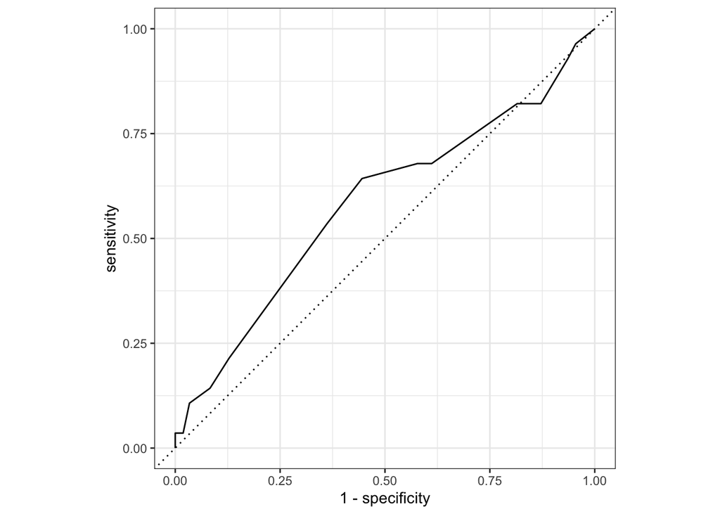

```r
#plot roc curve
gss16_test_aug |>
  roc_curve(truth = advfront, `.pred_Not agree`) |>
  autoplot()
```

```r
#Auroc value
gss16_test_aug |>
  roc_auc(truth = advfront, `.pred_Not agree`)
```

```
## # A tibble: 1 × 3
##   .metric .estimator .estimate
##   <chr>   <chr>          <dbl>
## 1 roc_auc binary         0.581
```